# Introduction to the normR package

Johannes Helmuth

2017-05-22

# Contents

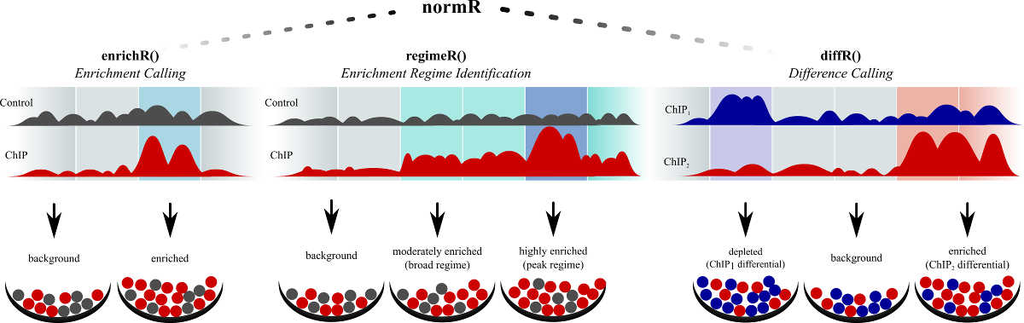

# 1 TL;DR (Too long; didn’t read)

- `enrichR()` calls ChIP-seq enrichment over control for coordinate-sorted and indexed bamfiles

```r
e <- enrichR(treatment = "ChIP.bam",
             control   = "Control.bam",
             genome    = "hg19")
```

- `diffR()` calls differential enrichment between two conditions, *i.e.* two ChIP-seq tracks

```r
de <- diffR(treatment = "ChIP1.bam",
            control   = "ChIP2.bam",
            genome    = "hg19")
```

- `regimeR()` calls `k` enrichment regimes in a ChIP-seq experiment over control

```r
re <- regimeR(treatment = "ChIP.bam",
              control   = "Control.bam",
              genome    = "hg19",
              models    = k)
```

- `exportR()` writes above results to bed, bedGraph or bigWig

```r
#export enriched regions with FDR<=10% for downstream analysis
exportR(obj      = e,
        filename = "enriched.bed",
        type     = "bed",
        fdr      = 0.1)
#or
#write normalized differential enrichment to bigWig for genome browser display
exportR(obj      = de,
        filename = "diffEnrichment.bw",
        type     = "bigWig")
```

- give credit if you benefit

```r
citation("normr")
```

```
##
##
##   Johannes Helmuth and Ho-Ryun Chung (2017). normr: Normalization
##   and difference calling in ChIP-seq data. R package version
##   1.3.1. https://github.com/your-highness/normR
##
## A BibTeX entry for LaTeX users is
##
##   @Manual{,
##     title = {normr: Normalization and difference calling in ChIP-seq data},
##     author = {Johannes Helmuth and Ho-Ryun Chung},
##     year = {2017},
##     note = {R package version 1.3.1},
##     url = {https://github.com/your-highness/normR},
##   }
```

# 2 Introduction to normR

Chromatin immunoprecipitation followed by sequencing (ChIP-seq) provides genome-wide localization data for DNA-associated proteins. To infer the regions bound by such proteins the read densities obtained by such a ChIP-seq experiment are compared to the corresponding read profile obtained by a control experiment. A meaningful comparison requires normalization to mitigate the effects of technical biases, *e.g.* different sequencing depth. But more importantly the effect of the enrichment of certain regions on the overall read statistics. Normalization requires knowledge of the regions that remained unchanged, such that normalization and difference calling are inseparable.

This package, *normR* (**n**ormR **o**beys **r**egime **m**ixture **R**ules), follows this logic and performs normalization and difference calling simultaneously to identify genomic regions enriched by the ChIP-procedure (`enrichR()`). In addition, normR enables the comparison between ChIP-seq data obtained from different conditions allowing for unraveling genomic regions that change their association with the ChIP-target (`diffR()`). Lastly, normR is capable to differentiate multiple regimes of enrichment, *i.e.* broad domains and sharp peaks (`regimeR()`). In brief, all these routines encompass three steps:

1. Count reads in fixed-size windows along the genome;
2. Fit a binomial mixture model by Expectation Maximization;
3. Assign each window a significance based on the fitted background component.

This vignette explains a common workflow of normR analysis on NGS data for calling enrichment, identification of differential ChIP-seq enrichment and stratification of enrichment regimes. Herein, we provide examples for the export of results to common data formats like bigWig and bed. We show how analysis statistics and diagnostic plots are helpful for studying results. In a latter section, we cover more advanced topics including the alteration of read counting strategies, the application of normR on user-defined regions (*e.g.* promoters) and the integration of Copy Number Variation information in differential ChIP-seq enrichment calls.

# 3 Toy Examples

## 3.1 `enrichR()`: Calling Enrichment with an Input Control

In this first section, we would like to call regions significantly enriched for reads in the ChIP-seq experiment given a Control alignment. Here, we analyze ChIP-seq data for both H3K4me3 (pointy enrichment) and H3K36me3 (broad enrichment) given an Input-seq control alignment originating from a human immortalized myelogenous leukemia line (K562). Using normR, we show that our representative region on human chromsome 1 (chr1:22500000-25000000) is enriched for H3K4me3 mostly at promoters and precludes H3K36me3 enrichment which is overrepresented in gene bodies.

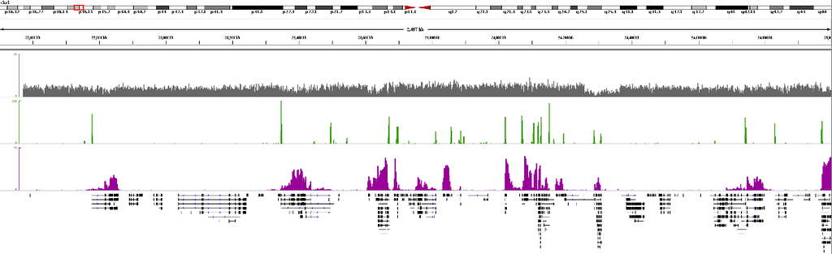

**IGV browser shot of Input (grey), H3K4me3 (green) and H3K36me3 (purple) alignment data on chr1 22.5Mb to 25Mb with genes (black) drawn.**

As part of the normR package, we provide 3 alignment files in bam format (Input, H3K4me3 and H3K36me3 ChIP-seq) containing reads for human chr1 22.5Mb to 25Mb. Note, bam files used in normR need to be sorted by read coordinates (`samtools sort x.bam x_sorted`) and indexed (`samtools index x_sorted.bam`). Our example files already fullfil this criteria.

*Firstly*, we retrieve filepaths for toy data:

```r
#Loading required package
library("normr")

inputBamfile <- system.file("extdata", "K562_Input.bam", package="normr")
k4me3Bamfile <- system.file("extdata", "K562_H3K4me3.bam", package="normr")
k36me3Bamfile <- system.file("extdata", "K562_H3K36me3.bam", package="normr")
```

*Secondly and lastly*, we need to specify the genome of the alignment. The `genome` argument can be a character specifying a UCSC genome identifier, *e.g.* “hg19”, or we can provide a 2-dimensional `data.frame` with columns seqnames and length. We will follow the later option: You can generate a genome `data.frame` yourself or can use `GenomeInfoDb` for retrieving the data.frame from UCSC for given genome identifier:

```r
#Fetch chromosome information
genome <- GenomeInfoDb::fetchExtendedChromInfoFromUCSC("hg19")

#Filter out irregular chromosomes and delete unnecessary columns
idx <- which(!genome$circular & genome$SequenceRole=="assembled-molecule")
genome <- genome[idx,1:2]
genome
```

```
##    UCSC_seqlevel UCSC_seqlength
## 1           chr1      249250621
## 2           chr2      243199373
## 3           chr3      198022430
## 4           chr4      191154276
## 5           chr5      180915260
## 6           chr6      171115067
## 7           chr7      159138663
## 8           chr8      146364022
## 9           chr9      141213431
## 10         chr10      135534747
## 11         chr11      135006516
## 12         chr12      133851895
## 13         chr13      115169878
## 14         chr14      107349540
## 15         chr15      102531392
## 16         chr16       90354753
## 17         chr17       81195210
## 18         chr18       78077248
## 19         chr19       59128983
## 20         chr20       63025520
## 21         chr21       48129895
## 22         chr22       51304566
## 23          chrX      155270560
## 24          chrY       59373566
```

```r
#Toy data has only "chr1"
genome <- genome[genome[,1] == "chr1",]
genome
```

```
##   UCSC_seqlevel UCSC_seqlength
## 1          chr1      249250621
```

*Now*, we are all set to do a enrichment call with default parameters:

```r
#Enrichment Calling for H3K4me3 and H3K36me3
k4me3Fit <- enrichR(treatment = k4me3Bamfile, control = inputBamfile,
                    genome = genome, verbose = FALSE)
k36me3Fit <- enrichR(treatment = k36me3Bamfile, control = inputBamfile,
                     genome = genome, verbose = FALSE)
```

That was easy and fast! You must know that all results are stored as `NormRFit-class` objects. They provide convenient access to count data and fitting results. For example, let’s have a look at some simple fitting statistics for H3K4me3:

```r
k4me3Fit
```

```
## NormRFit-class object
##
##  Type:                    enrichR
##  Number of Regions:       997003
##  Theta* (naive bg):       0.3928
##  Background component B:  1
##
## +++ Results of fit +++
## Mixture Proportions:
## Background     Class 1
##    94.997%      5.003%
## Theta:
## Background     Class 1
##    0.09148     0.92761
```

The “Type” of the `NormRFit` object is defined by the function generating it, *i.e.* `enrichR()`, `diffR()` or `regimeR()`. The “Number of Regions” is the number of 250bp bins along the specified genome (default binsize). The “Number of Components” is 2 (background and enriched) in the case of `enrichR()`. The parameter $\theta^*$ (“Theta* (naive bg)”) describes a naive background parametrization if the effect of enrichment is not taken into account. The actual $\theta_B$ is with ~0.09 much smaller than $\theta^*$ which allows for more sensitive enrichment calling. Furthermore, by looking at the “Mixture Proportions” we find H3K4me3 is enriched in ~5% of the windows. For H3K36me3, we find ~23% of the regions enriched.

```r
k36me3Fit
```

```
## NormRFit-class object
##
##  Type:                    enrichR
##  Number of Regions:       997003
##  Theta* (naive bg):       0.5143
##  Background component B:  1
##
## +++ Results of fit +++
## Mixture Proportions:
## Background     Class 1
##     76.75%      23.25%
## Theta:
## Background     Class 1
##     0.1131      0.8383
```